# Aula 11

Mahayana Godoy

# Binominal

# Conteúdo do dia

Muitas vezes queremos saber sobre a distribuição de ocorrências de uma variável dependente quantitativa. Em boa parte desses casos em pesquisa linguística, os nossos dados nos levam a questionar qual é a probablidade da ocorrência observada dada uma **distribuição binomial**.

Para a aula de hoje, usaremos o material da Profa [**Lívia Oushiro**](http://rpubs.com/oushiro/iel), inspirado no livro de Gries (2012). Vamos discutir:

- O que é a distribuição binomial
- Como gerar tabelas de contagem e frequência relativa das observações
- Como visualizar a distribuição dos dados com gráficos de barras
- Como fazer testes estatísticos com variáveis dependentes qualitativas

# Probabilidade de um evento de sucesso/fracasso

# Lançamento de uma moeda

Vamos lançar uma moeda. Se der cara, eu dou um real para vocês, se der coroa, vocês dão um real para mim. Vamos fazer 100 lançamentos. Vamos terminar, cada um, com quantos reais?

- R: assumindo que ninguém trapaceou, cada um de nós vai terminar com cerca de 50 reais
- $H_0$: eu não trapaceio, a chance de sair coroa é igual a de sair cara: 50% (ou uma probabilidade de 0.5).
- $H_\text{A1}$: eu trapaceio, a chance de sair coroa é maior que a de sair cara: p(coroa) > p(cara). **Teste monocaudal**
- $H_\text{A2}$: alguém trapaceia, as chances de sair cara ou coroa são diferentes: p(cara) ≠ p(coroa). **Teste Bicaudal**

# Lançamento de uma moeda

Se eu ganhar 52 reais e você ganhar 48, podemos rejeitar a $H_0$ alegando que p(coroa) > 0.5?

- E se eu ganhar 56 reais e você ganhar 44?
- E se eu ganhar 60 reais e você ganhar 40?
- E se eu ganhar 90 reais e você ganhar 10?
- Você pode fazer um teste estatístico para ver se eu sou honesta no jogo, mas dessa vez a nossa variável dependente (aquilo que medimos) não é quantitativa, mas **categórica**: cara ou coroa
- Vamos pensar em linguística: se duas variantes de uma variável (x1 e x2) variam livremente, sem preferência, então p(x1) = p(x2). Podemos coletar dados para testar essa hipótese!

# Lançamento de uma moeda

Para facilitar, imagine que vamos fazer apenas 3 lançamentos de moedas. Eu consigo prever, em uma tabela, os possíveis resultados desses três lançamentos:

[output not shown]

**Fonte:** adaptado de Gries (2013:34)

Qual a probabilidade de eu tirar 3 coroas?

- R: 0.125

# Lançamento de uma moeda

Qual a probabilidade de eu tirar apenas uma coroa?

| Lance 1 | Lance 2 | Lance 3 | # cara | # coroa | $p_\text{resultado}$ |
| --- | --- | --- | --- | --- | --- |
| cara | cara | cara | 3 | 0 | 0.125 |
| **cara** | **cara** | **coroa** | **2** | **1** | **0.125** |
| **cara** | **coroa** | **cara** | **2** | **1** | **0.125** |
| cara | coroa | coroa | 1 | 2 | 0.125 |
| **coroa** | **cara** | **cara** | **2** | **1** | **0.125** |
| coroa | cara | coroa | 1 | 2 | 0.125 |
| coroa | coroa | cara | 1 | 2 | 0.125 |
| coroa | coroa | coroa | 0 | 3 | 0.125 |

- $3 * 0.125 = 0.375$

# Lançamento de uma moeda

Qual a probabilidade de eu tirar AO MENOS uma coroa?

| Lance 1 | Lance 2 | Lance 3 | # cara | # coroa | $p_\text{resultado}$ |
| --- | --- | --- | --- | --- | --- |
| cara | cara | cara | 3 | 0 | 0.125 |
| **cara** | **cara** | **coroa** | **2** | **1** | **0.125** |
| **cara** | **coroa** | **cara** | **2** | **1** | **0.125** |
| **cara** | **coroa** | **coroa** | **1** | **2** | **0.125** |
| **coroa** | **cara** | **cara** | **2** | **1** | **0.125** |
| **coroa** | **cara** | **coroa** | **1** | **2** | **0.125** |
| **coroa** | **coroa** | **cara** | **1** | **2** | **0.125** |
| **coroa** | **coroa** | **coroa** | **0** | **3** | **0.125** |

- $7 * 0.125 = 0.875$
- $1-0.125 = 0.875$

# Lançamento de uma moeda

Nossa tabela tinha apenas 8 linhas, pois tinhamos apenas 3 lançamentos ($2^3 = 8$).

Se fizéssemos 100 lançamentos, teríamos $2^\text{100}$ linhas, ou 1.267651e+30 ocorrências.

Sim, esse é um número tão grande que o *R* não quis escrever inteiro, o que significa que nós não queremos fazer essa tabela na mão.

Felizmente, podemos usar a função `dbinom()` para saber as probabilidades de um número x de sucessos em *n* eventos considerando uma probabilidade *p*.

```r
dbinom(x, n, p)
```

# Lançamento de uma moeda

Qual a probabilidade de eu tirar 3 coroas em 3 lançamentos de moeda?

**x:** número de sucessos (quantas vezes eu tirei coroa; nesse caso, 3)

**n:** número de tentativas (número de lançamento de moedas; nesse caso, 3)

**p:** probabilidade do evento a cada tentativa (nesse caso, 0.5 segundo $H_0$)

```r
dbinom(x, n, p)
```

```r
dbinom(3, 3, 0.5)
```

```
## [1] 0.125
```

# Lançamento de uma moeda

Qual a probabilidade de eu tirar 1 coroa em 3 lançamentos de moeda?

**x:** número de sucessos: 1

**n:** número de tentativas: 3

**p:** probabilidade do evento a cada tentativa: 0.5

```r
dbinom(1, 3, 0.5)
```

```
## [1] 0.375
```

# Lançamento de uma moeda

Qual a probabilidade de eu tirar **ao menos** 1 coroa em 3 lançamentos de moeda?

Isso implica a probabilidade de tirar 1 coroa, 2 coroas e 3 coroas; informamos na função que nosso x é igual às possibilidades de no mínimo 1 e no máximo 3:

```r
dbinom(1:3, 3, 0.5)
```

```
## [1] 0.375 0.375 0.125
```

Isso nos dá a probabilidade de tirar 1 coroa, 2 coroas ou 3 coroas, respectivamente. A soma é igual ao 0.875 que já havíamos calculado.

```r
sum(dbinom(1:3, 3, 0.5))
```

```
## [1] 0.875
```

# A distribuição binomial

# Lançamento de uma moeda

O gráfico abaixo mostra as probabilidades de tirar 1, 2 ou 3 coroas em 3 lançamentos de moedas

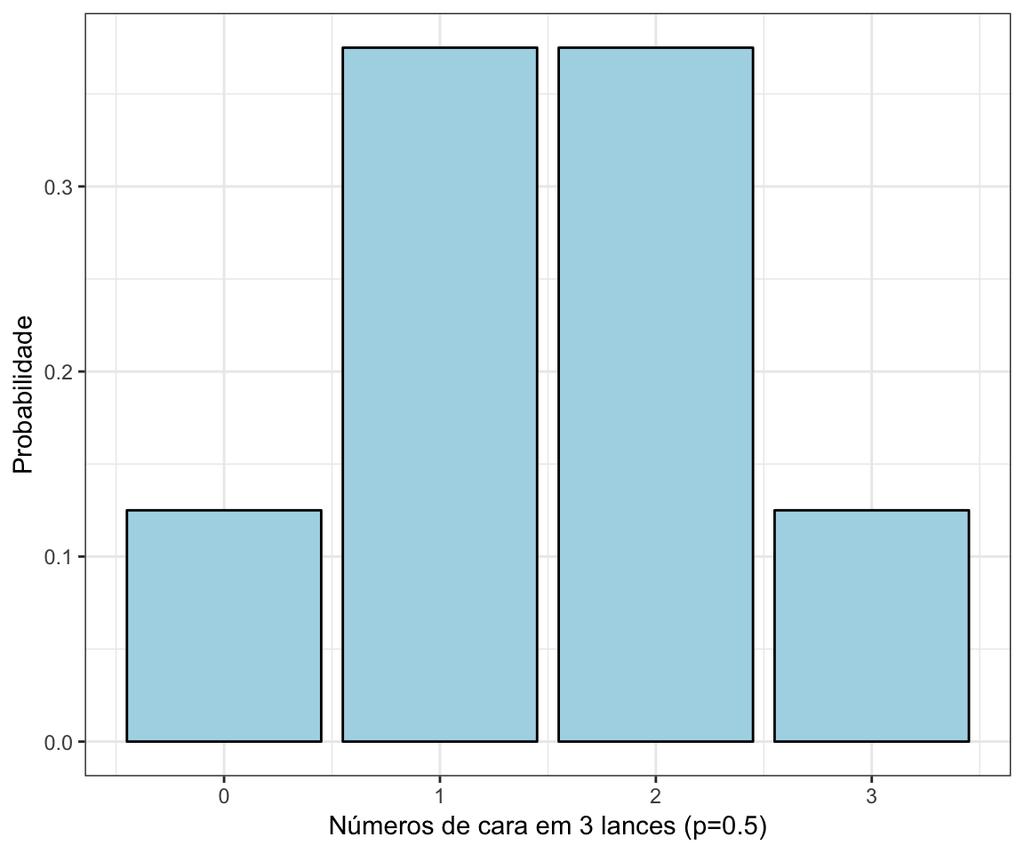

# Lançamento de uma moeda

O gráfico abaixo mostra as probabilidades de tirar 1, 2, 3, 4, 5, 6, 7, 8, 9 ou 10 coroas em 10 lançamento de moedas.

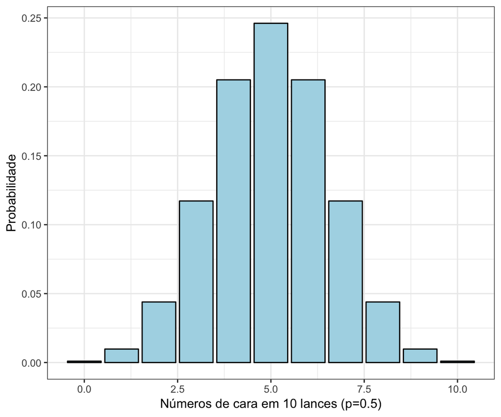

# Lançamento de uma moeda

A mesma lógica, mas para 100 lançamentos de moedas:

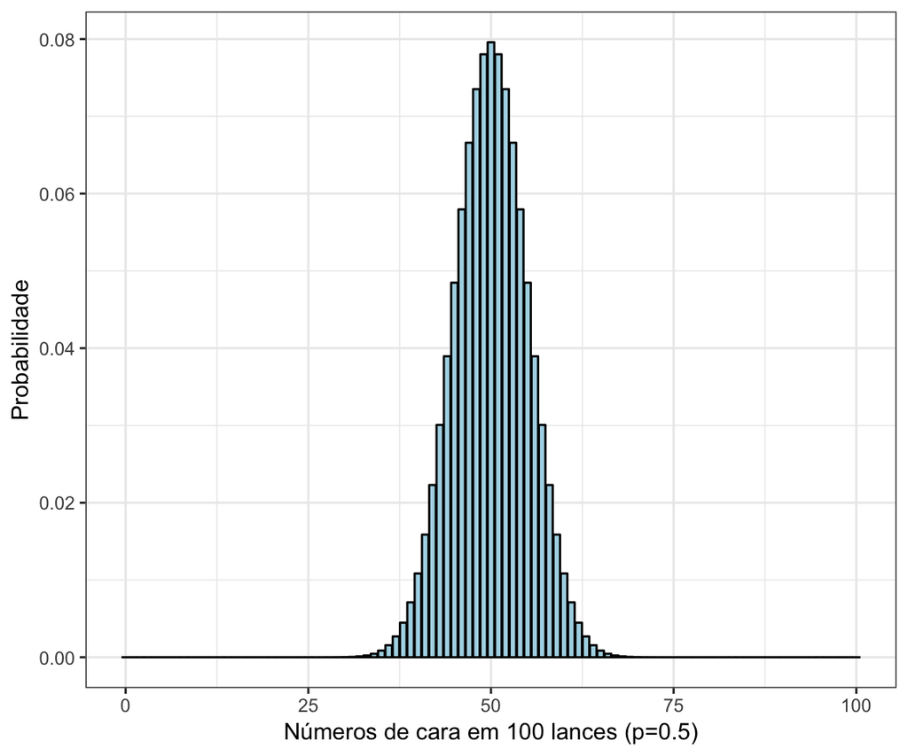

O que vai acontecer com o gráfico se eu fizer 1000 lançamentos?

# Lançamento de uma moeda

A mesma lógica, mas para 1000 lançamentos de moedas:

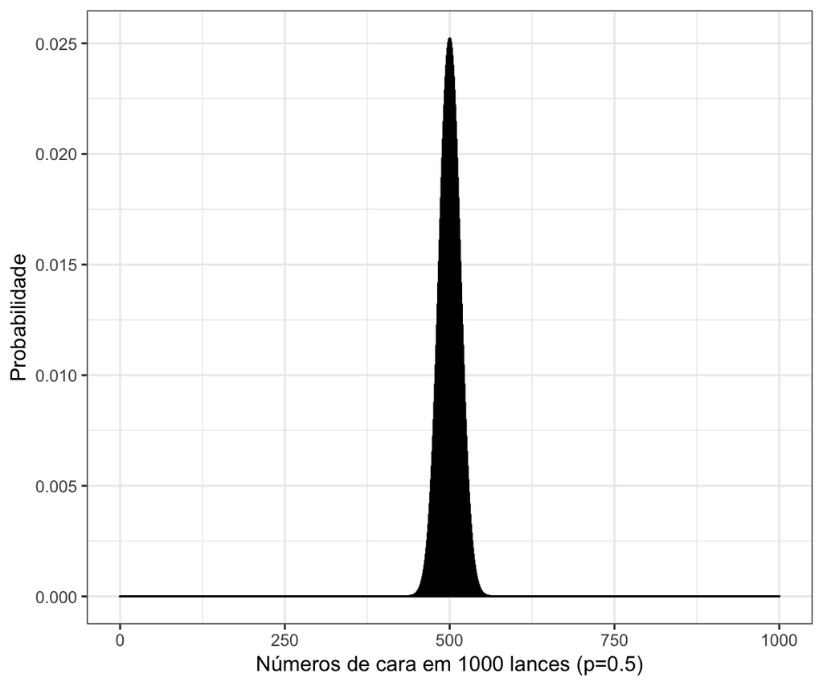

# Lançamento de uma moeda

É possível eu jogar uma moeda 1000 vezes e tirar cara 900 vezes (linha vermelha)? Sim, mas é *improvável* dada $H_0$.

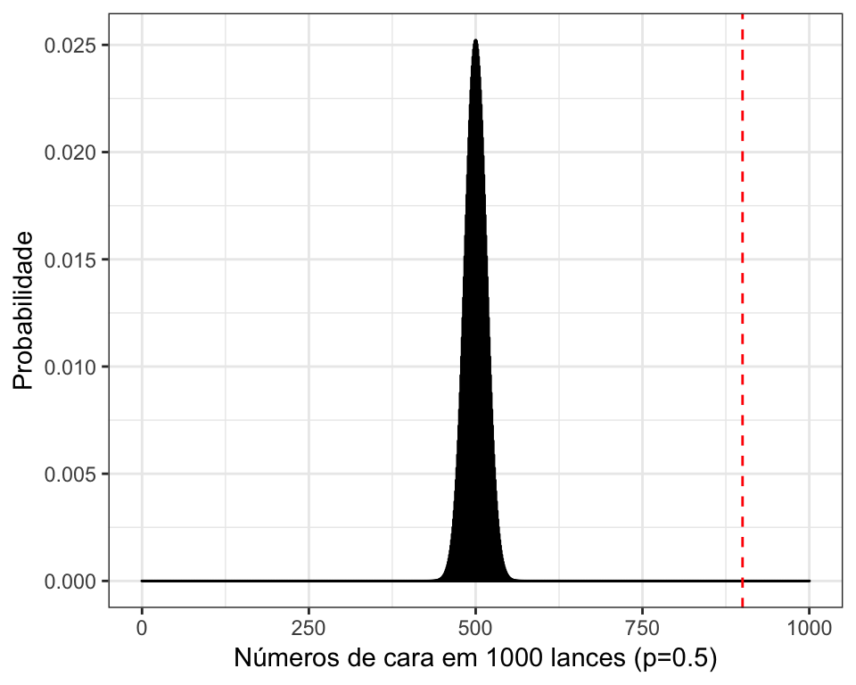

A essa altura, você já percebeu que temos aqui a mesma lógica de teste de hipóteses que aplicávamos a uma distribuição normal.

# Distribuição binomial

Normal e Binomial são distribuições que eu assumo que podem modelar a resposta de um experimento. A principal diferença diz respeito ao tipo de informação mostrada por dados que se organizam em uma distribuição normal e uma binominal.

Na **distribuição normal**, temos a probabilidade de ocorrência um valor resultante de uma mensuração.

Na **distribuição binomial**, temos a probabilidade de *x* sucessos em *n* ocorrências de um evento, assumindo que esse evento possa ter apenas dois resultados possíveis, como cara/coroa, erro/acerto, brasileiro/estrangeiro, retroflexo/não-retroflexo, tu/você etc.

À semelhança de uma normal, podemos ver a distribuição binomial como uma distribuição de probabilidades.

# Binomial e probabilidades

Podemos ver que o histograma de uma binomial serve também para nos dar uma ideia da probabilidade de eu tirar x sucessos em n tentativas. Vamos lembrar minha pergunta:

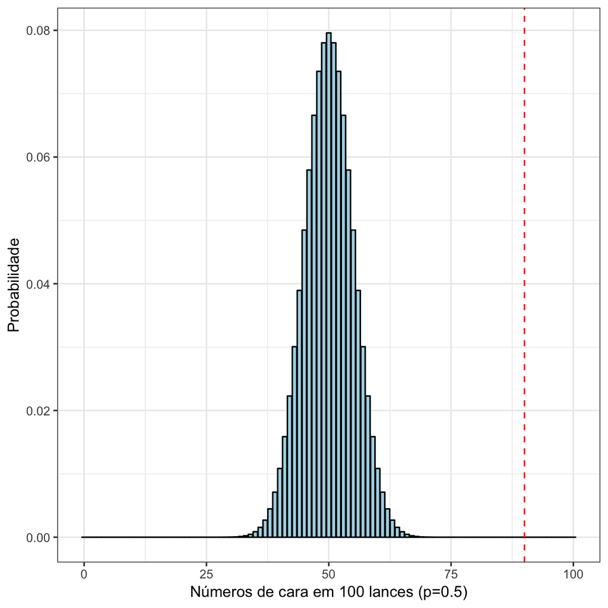

Se eu ganhar 90 reais e você 10, posso rejeitar a $H_0$ de que p(coroa) = 0.5?

A linha tracejada no gráfico marca o valor 90 no eixo x.

# Binomial e probabilidades

Podemos usar a função `dbinom()` para saber a probabilidade de tirar coroa pelo menos 90 vezes em 100 tentativas.

```r
sum(dbinom(90:100, 100, 0.5))
```

```
## [1] 1.531645e-17
```

Assumindo um $\alpha$ de 0.05, podemos rejeitar a $H_0$, e você pode me mostrar essa estatística para exigir que eu te devolva os 90 reais: é muito improvável que esse resultado possa ter sido obtido se eu não fiz alguma alteração na moeda…

# Binomial: pressuposições

Para que um fenômeno possa ter seus resultados modelados por meio de uma distribuição binomial, é preciso que estejam presentes três critérios:

**Critério 1: o fenômeno produz um de dois resultados possíveis, chamados de sucesso e fracasso.**

A frequência da cor dos olhos das pessoas não poderia ser modelado a partir de uma binomial, pois os resultados possíveis são verde, azul, castanho claro, castanho escuro… No entanto, é possível que um pesquisador esteja preocupado com os genes associados a ocorrência de olhos verdes. Nesse caso, ele pode modelar o fenômeno como uma binomial ao classificar os dados como “olho verde”/“olho não-verde”.

# Binomial: pressuposições

Para que um fenômeno possa ter seus resultados modelados por meio de uma distribuição binomial, é preciso que estejam presentes três critérios:

**Critério 2: a probabilidade de sucesso é a *mesma* do início ao fim do experimento.**

Suponha que eu tenha 10 bolinhas em uma caixa, 5 pretas, 5 vermelhas. A probabilidade de eu tirar uma bolinha vermelha é 5/10 (0.5). Suponha que eu vá tirando as bolinhas sem repô-las à caixa. Tiro a primeira bolinha e ela é preta. Agora minha probabilidade de tirar uma bolinha vermelha mudou: é 5/9. Tiro uma segunda bolinha, ela é preta novamente. Na terceira tentativa, a probabilidade de tirar a bolinha vermelha é 5/8.

Nesse caso, a probabilidade muda a cada bolinha tirada. O resultado desse experimento *não* pode ser modelado por uma distribuição binomial!

# Binomial: pressuposições

Para que um fenômeno possa ter seus resultados modelados por meio de uma distribuição binomial, é preciso que estejam presentes três critérios:

**Critério 3: As tentativas devem ser independentes.**

Isso significa que a probabilidade de sucesso de uma tentativa não deve depender da tentativa anterior. Como exemplo, considere uma sentença em português com *n* palavras. A probabilidade de algumas dessas palavras ser uma preposição não é independente do resultado da palavra anterior. Pense: se houver uma preposição, a palavra seguinte dificilmente será outra preposição; se houver um verbo, é possível que a palavra seguinte seja uma preposição. Ou seja, a ocorrência de uma preposição na frase *não é* independente da categoria gramatical da palavra anterior.

# Testes de proporção

# Avaliando a probabilidade de n sucessos

O resultado de um evento que compõe uma distribuição **bi**nomial é sempre um de dois possíveis.

Se um evento tem p(sucesso) = 0.7, isso significa que a cada 10 lances, 7 resultam em um sucesso e 3 em um fracasso.

Se um evento tem p(sucesso) = 0.5, isso significa que a cada 10 lances, 5 são sucessos e 5 são fracassos.

Geralmente, queremos testar se o valor observado de sucesso é diferente da probabilidade que supunhamos.

# Avaliando a probabilidade de n sucessos

No caso das nossas moedas, estamos desconfiados que p(coroa) > p(cara). Portanto, fazemos um teste de proporção para indagar se o número de sucessos observados (x) em n eventos é **maior** que uma probabilidade de 0.5.

O comando `prop.test()` faz exatamente isso.

```r
#prop.test(x, n, p, alternative = )

prop.test(90, 100, 0.5, alternative = "greater") ##você quer saber se a probabilidade de tirar coroa é maior que 0.5 dados os x e n informados
```

# Avaliando a probabilidade de n sucessos

```r
prop.test(90, 100, 0.5, alternative = "greater")
```

```
##
##  1-sample proportions test with continuity correction
##
## data:  90 out of 100, null probability 0.5
## X-squared = 62.41, df = 1, p-value = 1.395e-15
## alternative hypothesis: true p is greater than 0.5
## 95 percent confidence interval:
##  0.8337632 1.0000000
## sample estimates:
##   p
## 0.9
```

Perceba que o teste calculou a p(coroa) (0.9, na última linha) e considerou a $H_A$ de que esse valor é maior que 0.5. Nesse caso, o p-valor (1.39e-15) nos permite rejeitar a $H_0$ em favor da $H_A$.

# Avaliando a probabilidade de n sucessos

```r
prop.test(90, 100, 0.5, alternative = "greater")
```

```
##
##  1-sample proportions test with continuity correction
##
## data:  90 out of 100, null probability 0.5
## X-squared = 62.41, df = 1, p-value = 1.395e-15
## alternative hypothesis: true p is greater than 0.5
## 95 percent confidence interval:
##  0.8337632 1.0000000
## sample estimates:
##   p
## 0.9
```

*Um teste de proporção indicou que a probabilidade de ocorrência de coroa é significativamente maior que 0.5 ($X^2$(1) = 62.41, p = 0)*

# Prática 1

# Problemas de linguistas

Dois sociolinguistas divergem sobre uma hipótese envolvendo os usos de “tu” e “você” para uma determinada população. O sociolinguista A acaba de publicar um paper afirmando que essas variantes ocorrem com igual frequência na língua dessa população. No entanto, o sociolinguista B diz que o contexto informal prevê o uso de “tu” em uma taxa maior do que “você”.

O sociolinguista B, para provar seu ponto, coleta dados de situações informais de fala. Ao todo, ele contabiliza 132 ocorrências de “tu” e “você” somadas. Há 80 ocorrências de “tu” e 52 de “você”.

Como testar se há evidências a favor da hipótese do sociolinguista B?

# Construindo o teste

$H_0$: em contextos informais, p(tu) = p(você) = 0.5 (tese do Linguista A)

$H_A$: em contextos informais, p(tu) > 0.5 (tese do Linguista B)

**x:** 80

**n:** 132

**p:** 0.5

```r
prop.test(80, 132, 0.5, alternative = "greater")
```

# Analisando e escrevendo o resultado

```r
prop.test(80, 132, 0.5, alternative = "greater")
```

```
##
##  1-sample proportions test with continuity correction
##
## data:  80 out of 132, null probability 0.5
## X-squared = 5.5227, df = 1, p-value = 0.009385
## alternative hypothesis: true p is greater than 0.5
## 95 percent confidence interval:
##  0.5308258 1.0000000
## sample estimates:
##         p
## 0.6060606
```

*Um teste de proporção indicou que a probabilidade de uso de “tu” em contextos informais é significativamente maior que 0.5 ($X^2$(1) = 5.52, p = 0.009).*

# Lembrete

Lembre-se de que sua $H_A$ pode mudar, e isso mudará como você preenche o parâmetro *alternative*

```r
prop.test(80, 132, 0.5, alternative = "greater")
prop.test(80, 132, 0.5, alternative = "less")
prop.test(80, 132, 0.5, alternative = "two.sided")
```

# Testes de proporção e chi-quadrado

# Labov

Você já deve ter ouvido falar do trabalho de Labov sobre a realização do [r] pós-vocalico no inglês de Nova Iorque.

Labov quis testar se o tipo de realização de [r] é um diferenciador social na fala nova-iorquina. Para isso, ele coletou informação com vendedoras de 3 lojas de departamento, com público de classes sociais diferentes: *Klein* (classe média baixa), *Macy’s* (classe média) e *Sacks* (classe média alta).

# Labov

O autor abordava as vendedoras de modo a perguntar onde ficava algum item, cuja resposta seria necessariamente “fouRth flooR”. Além disso, a pergunta era feita de modo a forçar a vendedora a dar uma resposta casual e uma mais planejada.

**E:** Excuse me, where are x?

**I:** Forth floor (fala casual)

**E:** Excuse me?

**I:** Forth floor (fala planejada, enfática)

Você tem uma amostra dos dados coletados no arquivo labov.csv (que é uma edição do conjunto disponibilizado pela Profa. Livia Oushiro). Importe o conjunto de dados, chame-o de “labov” e o inspecione.

# Labov

Abaixo, há uma síntese das variáveis da tabela e seus níveis

**r:** “r1” (rótico realizado; variante de prestígio); “r0” (rótico apagado)

**store:** “Saks”, “Klein”, “Macys”

**emphasis:** “casual”, “emphatic”

**word:** “flooR”, “fouRth”

**Primeira pergunta:** No geral, as atendentes preferiram usar a forma de maior prestígio (r1) ou de menor prestígio; ou seja, será que p(r1) ≠ p(r0)?

# Tabelas de contingência

Com a função `table()`, podemos criar uma *tabela de contingência*: uma tabela que resuma quantas ocorrências de cada tipo de [r] há na amostra (o que chamamos de frequência absoluta)

```r
tabela = table(labov$r)
tabela
```

```
##
##  r0  r1
## 499 231
```

Bem mais fácil do que fazer isso no excel, né?

Vemos que há, no total, 730 respostas anotadas: 499 ocorrências de r0 (quando o rótico é apagado) e 231 ocorrências de r1 (quando o rótico é realizado, a variante de maior prestígio).

**Será que essa diferença é significativa?**

# Tabelas de contingência

Antes de fazer um teste, vamos ver a proporção desses dados no total de respostas anotadas.

Com a função `prop.table`, você transforma a tabela especificada em seu argumento em uma tabela de frequência relativa.

```r
prop.table(tabela)
```

```
##
##        r0        r1
## 0.6835616 0.3164384
```

De novo: bem mais fácil que no excel, né? Nunca mais use o excel para fazer contagem de células na sua vida!

# Gráfico de barras

Valores do tipo contagem ou proporção são melhores observados com um gráfico de barras. A sintaxe para fazermos um gráfico da contagem de [r] no ggplot é a seguinte:

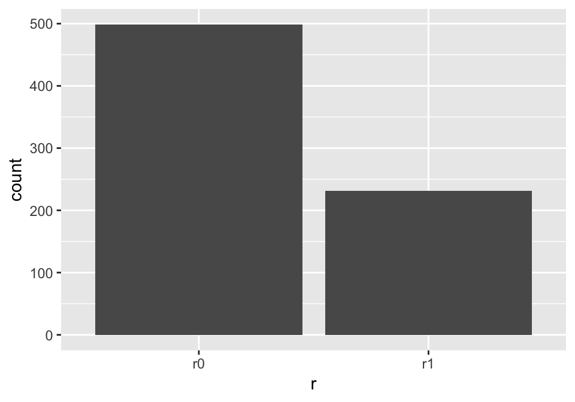

```r
ggplot(labov, aes(x=r))+ #não especificamos o eixo y, pois o default do r é entendê-lo como contagem
  geom_bar() ## especifica que o gráfico é um gráfico de barras!
```

# Gráfico de barras

Fazer um gráfico com a porcentagem de ocorrências é meio chato, mas vamos lá.

Na Linha A, abaixo, eu especifico a estética da barra: no eixo y, quero a contagem dividida pela soma total de ocorrências (essa é a conta que fazemos para tirar uma probabilidade!)

```r
ggplot(labov, aes(x=r))+
  geom_bar(aes( y = (..count..)/sum(..count..))) # Linha A
```

# Gráfico de barras

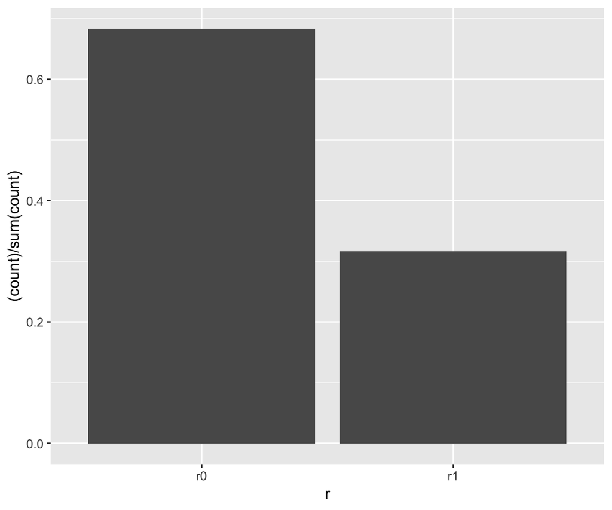

```r
ggplot(labov, aes(x=r))+
  geom_bar(aes( y = (..count..)/sum(..count..))) ## Linha A
```